# Manifesto Project

## The Manifesto Project with `manifestoR`

[The Manifesto Project](https://manifesto-project.wzb.eu/) collects and organizes political party manifestos from around the world. It currently covers over 1000 parties from 1945 until today in over 50 countries on five continents. We can use the [`manifestoR` package](https://github.com/ManifestoProject/manifestoR) to access the API and download those manifestos for analysis in R.

### Load library and set API key

## API authentication

Accessing data from the Manifesto Project API requires an authentication key. You can create an account and key [here](https://manifesto-project.wzb.eu/signup). Here I store my key in `.Rprofile` and retrieve it using `mp_setapikey()` (different packages have different storage methods).

### Retrieve the database

```r
(mpds <- mp_maindataset())
```

```
## Connecting to Manifesto Project DB API...
## Connecting to Manifesto Project DB API... corpus version: 2024-1
```

```
## # A tibble: 5,151 × 175
##    country countryname oecdmember eumember edate        date party partyname
##      <dbl> <chr>            <dbl>    <dbl> <date>      <dbl> <dbl> <chr>
##  1      11 Sweden               0        0 1944-09-17 194409 11220 Communist Pa…
##  2      11 Sweden               0        0 1944-09-17 194409 11320 Social Democ…
##  3      11 Sweden               0        0 1944-09-17 194409 11420 People’s Par…
##  4      11 Sweden               0        0 1944-09-17 194409 11620 Right Party
##  5      11 Sweden               0        0 1944-09-17 194409 11810 Agrarian Par…
##  6      11 Sweden               0        0 1948-09-19 194809 11220 Communist Pa…
##  7      11 Sweden               0        0 1948-09-19 194809 11320 Social Democ…
##  8      11 Sweden               0        0 1948-09-19 194809 11420 People’s Par…
##  9      11 Sweden               0        0 1948-09-19 194809 11620 Right Party
## 10      11 Sweden               0        0 1948-09-19 194809 11810 Agrarian Par…
## # ℹ 5,141 more rows
## # ℹ 167 more variables: partyabbrev <chr>, parfam <dbl>, candidatename <chr>,
## #   coderid <dbl>, manual <dbl>, coderyear <dbl>, testresult <dbl>,
## #   testeditsim <dbl>, pervote <dbl>, voteest <dbl>, presvote <dbl>,
## #   absseat <dbl>, totseats <dbl>, progtype <dbl>, datasetorigin <dbl>,
## #   corpusversion <chr>, total <dbl>, peruncod <dbl>, per101 <dbl>,
## #   per102 <dbl>, per103 <dbl>, per104 <dbl>, per105 <dbl>, per106 <dbl>, …
```

`mp_maindataset()` includes a data frame describing each manifesto included in the database. You can use this database for some exploratory data analysis. For instance, how many manifestos have been published by each political party in Sweden?

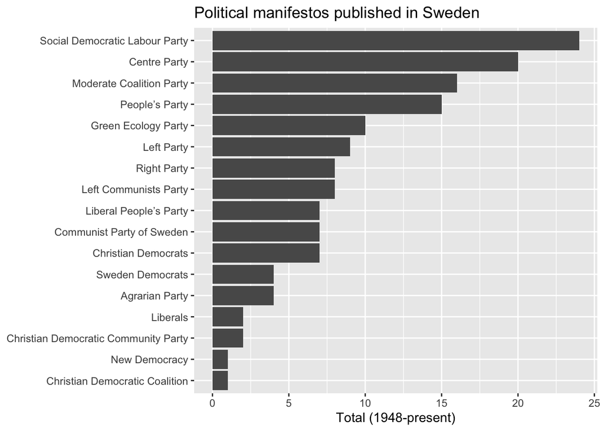

```r
mpds %>%
  filter(countryname == "Sweden") %>%
  count(partyname) %>%
  ggplot(aes(fct_reorder(partyname, n), n)) +
  geom_col() +
  labs(
    title = "Political manifestos published in Sweden",
    x = NULL,
    y = "Total (1948-present)"
  ) +
  coord_flip()
```

Or we can use **scaling functions** to identify each party manifesto on an ideological dimension. For example, how have the Democratic and Republican Party manifestos in the United States changed over time?

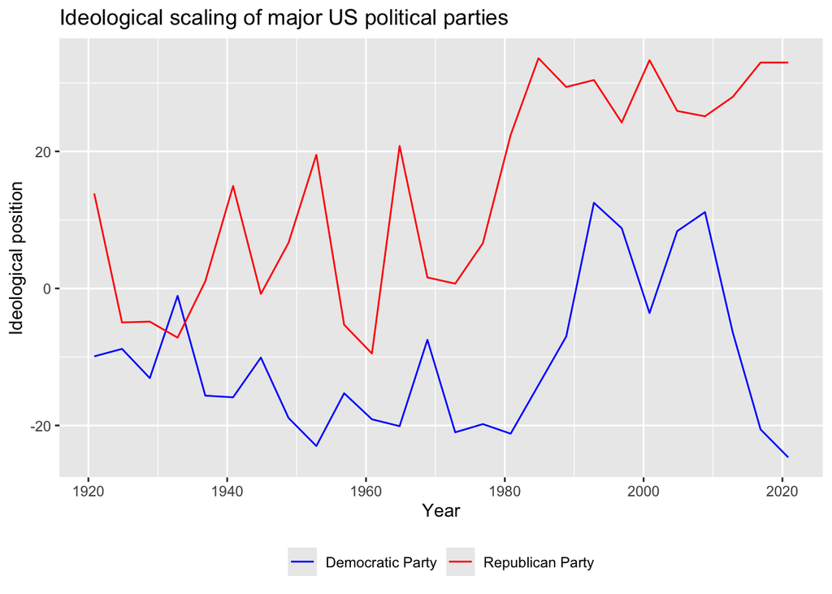

```r
mpds %>%
  filter(party == 61320 | party == 61620) %>%
  mutate(ideo = mp_scale(.)) %>%
  select(partyname, edate, ideo) %>%
  ggplot(aes(edate, ideo, color = partyname)) +
  geom_line() +
  scale_color_manual(values = c("blue", "red")) +
  labs(
    title = "Ideological scaling of major US political parties",
    x = "Year",
    y = "Ideological position",
    color = NULL
  ) +
  theme(legend.position = "bottom")
```

### Download manifestos

```r
# download documents
(docs <- mp_corpus(countryname == "United States" & edate > as.Date("2016-01-01")))
```

```
## Connecting to Manifesto Project DB API... corpus version: 2024-1
## Connecting to Manifesto Project DB API... corpus version: 2024-1
```

```
## <<ManifestoCorpus>>
## Metadata:  corpus specific: 0, document level (indexed): 0
## Content:  documents: 4
```

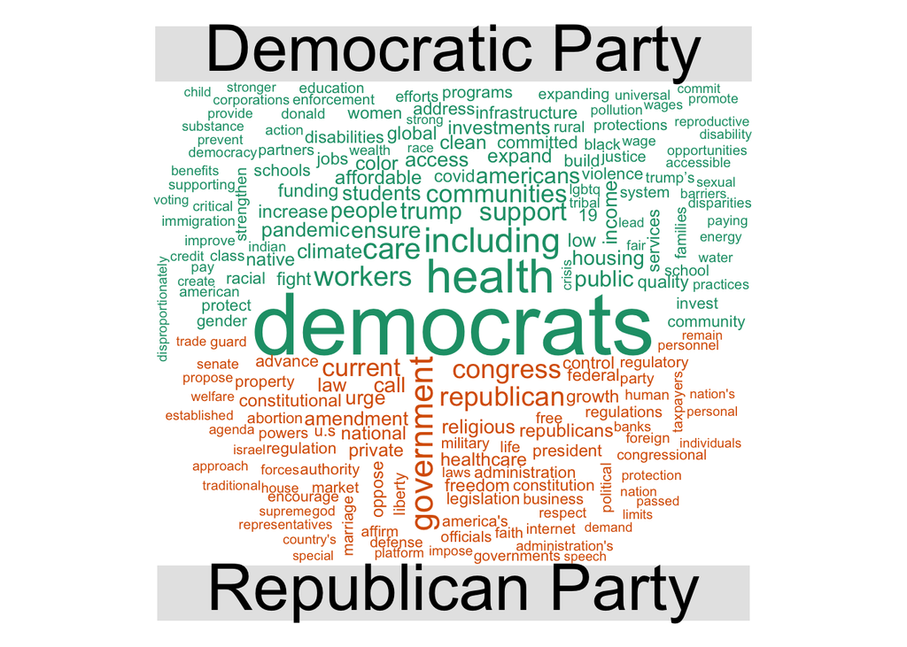

```r
# generate wordcloud of most common terms
docs %>%
  tidy() %>%
  mutate(party = factor(party,
    levels = c(61320, 61620),
    labels = c("Democratic Party", "Republican Party")
  )) %>%
  unnest_tokens(word, text) %>%
  anti_join(stop_words) %>%
  count(party, word, sort = TRUE) %>%
  drop_na() %>%
  reshape2::acast(word ~ party, value.var = "n", fill = 0) %>%
  comparison.cloud(max.words = 200)
```

```r
write_csv(mpds, "../data/manifesto_mpds.csv")
```